# Simulação de Dados e Avaliação de Métodos de Imputação para a idade do pai

mIRNA

2025-01-29

# Passos para simulação (Oberman, 202x):

0. Antes, Objetivos da simulação:
   - Desenho da simulação (incluir pseudo-código ou diagrama de fluxo).
   - Estabelecer nível de precição necessário. (incluir número de simulações que serão precisas)
1. Métodos de geração do dado ‘real’
   - Fonte dos dados simulados (baseada em modelo ou baseada em design, fonte de variabilidade para indicar incerteza sobre os valores imputados)
2. Métodos de geração do missing simulado (MCAR, MAR, NMAR)
3. Métodos de imputação
4. Métodos de análise (obj.: avaliação da qualidade da imputação para determinar os limites de confiabilidade)

## Métodos de geração do dado ‘real’

### Cuidados para a geração dos dados ‘reais’, o que Gerkovink e Oberman chamam de ‘*verdade fundante simulada*’

#### Compreender a estrutura dos dados

- **Relação entre as variáveis**: Identificar as variáveis de interesse e suas relações (e.g., correlação).
- **Propriedades estatísticas**: Analisar estatísticas resumo (média, variância, assimetria, etc.) e checar se os dados seguem alguma distribuição de probabilidade conhecida (e.g., normal, exponêncial).

```r
load("E:/2-nao_subi_git20241101/Parana.RData")
```

##### Relação entre as variáveis: Identificar as variáveis de interesse e suas relações (e.g., correlação).

```r
colnames(Parana)
```

Avaliando a documentação. Esse trecho visualiza a sessão da DN onde estão presentes as categorias associadas ao preenchimento da DN:

```r
#Estrutura_SINASC <- read_excel("E:/DOCS SINASC/Estrutura_SINASC_para_CD.xlsx")
#View(Estrutura_SINASC_para_CD)
ver = Estrutura_SINASC %>%
  filter(`Sessão da DN`== "VII -\r\nPreenchimento") %>%
  print()
```

```r
ver = Estrutura_SINASC %>%
  filter(`Nome do campo no DBF`== "QTDGESTANT") %>%
  print()
```

```r
Parana = Parana %>%
  select("CODESTAB","CODMUNNASC","LOCNASC","IDADEMAE","ESTCIVMAE","ESCMAE","CODOCUPMAE", "QTDFILVIVO","CODMUNRES","GESTACAO","GRAVIDEZ","PARTO", "DTNASC","HORANASC","SEXO","RACACOR","RACACORMAE","NUMEROLOTE","DIFDATA","ESCMAE2010","SERIESCMAE", "DTNASCMAE" ,"QTDGESTANT","IDADEPAI","STCESPARTO","CODUFNATU","TPFUNCRESP","TPDOCRESP","DTDECLARAC","munResStatus","munResTipo","munResNome","munResUf","munResLat","munResLon","um","Ano","missing")
```

#### Filtra idades do pai e da mãe para o intervalo plausível - demograficamente falando (retira valores discrepantes)

```r
Parana <- Parana %>%
  filter(
   (is.na(IDADEPAI) | (IDADEPAI >= 15 & IDADEPAI <= 59)),
    IDADEMAE >= 15 & IDADEMAE <= 49
  )

Parana <- Parana %>%
  mutate(
     IDADEPAI= as.numeric(IDADEPAI),
      IDADEMAE= as.numeric(IDADEMAE)
  )
```

```r
glimpse(Parana)
```

### Pequeno resumo dos dados sem tratamentos:

#### Média das idades do pai e da mãe, assim como quantidade de NAs

```r
library(knitr)
# Selecionar colunas relevantes e resumir
custom_summary <- Parana %>%
  summarise(
    Total_Observacoes = n(),
    Media_IdadeMae = mean(as.numeric(IDADEMAE), na.rm = TRUE),
    Media_IdadePai = mean(as.numeric(IDADEPAI), na.rm = TRUE),
    Total_NAs_IdadeMae = sum(is.na(IDADEMAE)),
    Total_NAs_IdadePai = sum(is.na(IDADEPAI)),
  )

# Exibir como tabela formatada
kable(custom_summary, caption = "Resumo de Parana")
```

Resumo de Parana

| Total_Observacoes | Media_IdadeMae | Media_IdadePai | Total_NAs_IdadeMae | Total_NAs_IdadePai |
| --- | --- | --- | --- | --- |
| 1668384 | 27,0373 | 30,58519 | 0 | 391382 |

#### Resumo conjunto de dados Parana (pacote skim)

```r
library(skimr)
library(kableExtra)
 resumo_skim_df_original = skim(Parana)

# Salvar a tabela em formato LaTeX
latex_table <- resumo_skim_df_original %>%
  kable("latex", booktabs = TRUE, caption = "Resumo conjunto de dados Parana") %>%
  kable_styling(latex_options = c("hold_position", "striped"))

# Exportar a tabela para um arquivo .tex
#cat(latex_table, file = "skim_summary.tex")

resumo_skim_df_original
```

Data summary

| Name | Parana |
| --- | --- |
| Number of rows | 1668384 |
| Number of columns | 38 |
| Key | NULL |
| _______________________ |  |
| Column type frequency: |  |
| character | 33 |
| numeric | 5 |
| ________________________ |  |
| Group variables | None |

**Variable type: character**

| skim_variable | n_missing | complete_rate | min | max | empty | n_unique | whitespace |
| --- | --- | --- | --- | --- | --- | --- | --- |
| CODESTAB | 6313 | 1,00 | 7 | 7 | 0 | 1400 | 0 |
| CODMUNNASC | 0 | 1,00 | 6 | 6 | 0 | 729 | 0 |
| LOCNASC | 43 | 1,00 | 6 | 30 | 0 | 4 | 0 |
| ESTCIVMAE | 9004 | 0,99 | 5 | 22 | 0 | 5 | 0 |
| ESCMAE | 6046 | 1,00 | 1 | 15 | 0 | 6 | 0 |
| CODOCUPMAE | 1303 | 1,00 | 4 | 51 | 0 | 1892 | 0 |
| QTDFILVIVO | 9359 | 0,99 | 1 | 2 | 0 | 20 | 0 |
| CODMUNRES | 0 | 1,00 | 6 | 6 | 0 | 400 | 0 |
| GESTACAO | 16329 | 0,99 | 15 | 19 | 0 | 6 | 0 |
| GRAVIDEZ | 1382 | 1,00 | 5 | 13 | 0 | 3 | 0 |
| PARTO | 891 | 1,00 | 7 | 7 | 0 | 2 | 0 |
| DTNASC | 0 | 1,00 | 10 | 10 | 0 | 4018 | 0 |
| HORANASC | 1127 | 1,00 | 4 | 5 | 0 | 1441 | 0 |
| SEXO | 143 | 1,00 | 8 | 9 | 0 | 2 | 0 |
| RACACOR | 14418 | 0,99 | 5 | 8 | 0 | 5 | 0 |
| RACACORMAE | 18588 | 0,99 | 1 | 8 | 0 | 6 | 0 |
| NUMEROLOTE | 1 | 1,00 | 8 | 8 | 0 | 1885 | 0 |
| DIFDATA | 1 | 1,00 | 1 | 3 | 0 | 796 | 0 |
| ESCMAE2010 | 8273 | 1,00 | 1 | 1 | 0 | 7 | 0 |
| SERIESCMAE | 690264 | 0,59 | 1 | 1 | 0 | 9 | 0 |
| DTNASCMAE | 7813 | 1,00 | 10 | 10 | 0 | 14739 | 0 |
| QTDGESTANT | 11591 | 0,99 | 1 | 2 | 0 | 39 | 0 |
| STCESPARTO | 145072 | 0,91 | 1 | 1 | 0 | 4 | 0 |
| CODUFNATU | 179369 | 0,89 | 2 | 2 | 0 | 27 | 0 |
| TPFUNCRESP | 411904 | 0,75 | 1 | 1 | 0 | 5 | 0 |
| TPDOCRESP | 310326 | 0,81 | 1 | 1 | 0 | 6 | 0 |
| DTDECLARAC | 317893 | 0,81 | 10 | 10 | 0 | 3296 | 0 |
| munResStatus | 0 | 1,00 | 5 | 5 | 0 | 2 | 0 |
| munResTipo | 0 | 1,00 | 5 | 5 | 0 | 2 | 0 |
| munResNome | 0 | 1,00 | 4 | 27 | 0 | 400 | 0 |
| munResUf | 0 | 1,00 | 6 | 6 | 0 | 1 | 0 |
| munResLat | 11 | 1,00 | 7 | 9 | 0 | 399 | 0 |
| munResLon | 11 | 1,00 | 6 | 9 | 0 | 398 | 0 |

**Variable type: numeric**

| skim_variable | n_missing | complete_rate | mean | sd | p0 | p25 | p50 | p75 | p100 | hist |
| --- | --- | --- | --- | --- | --- | --- | --- | --- | --- | --- |
| IDADEMAE | 0 | 1,00 | 27,04 | 6,53 | 15 | 22 | 27 | 32 | 49 | ▆▇▇▂▁ |
| IDADEPAI | 391382 | 0,77 | 30,59 | 7,48 | 15 | 25 | 30 | 35 | 59 | ▃▇▆▁▁ |
| um | 0 | 1,00 | 1,00 | 0,00 | 1 | 1 | 1 | 1 | 1 | ▁▁▇▁▁ |
| Ano | 0 | 1,00 | 2016,90 | 3,13 | 2012 | 2014 | 2017 | 2020 | 2022 | ▇▆▆▅▅ |
| missing | 0 | 1,00 | 0,23 | 0,42 | 0 | 0 | 0 | 0 | 1 | ▇▁▁▁▂ |

#### Cria objeto reduzido, pai, mae, ano, missing

```r
pai_mae = Parana |>
  select(IDADEPAI, IDADEMAE,missing, Ano) |>
  group_by(Ano)
gc()
```

```
##            used  (Mb) gc trigger   (Mb)  max used   (Mb)
## Ncells  2744799 146,6    6456931  344,9   6456931  344,9
## Vcells 69327994 529,0  160106604 1221,6 160099774 1221,5
```

### Teste MCAR de Little’s

```r
# Restringir o teste MCAR a variáveis específicas
resultado_mcar <- naniar::mcar_test(pai_mae[, c("IDADEMAE", "IDADEPAI")])

# Exibir o resultado
print(resultado_mcar$p.value)
```

```
## [1] 0
```

**Resultados:** Se o p-valor for maior que 0.05, os dados para essas variáveis são considerados MCAR. Se for menor ou igual a 0.05, rejeita-se a hipótese de MCAR.

# Código para gerar os dados:

##### A princípio, os dados reais representam melhor a distribuição dos dados

Ao gerar dados sintéticos com distribuições definidas (rtruncnorm(), rnorm(), etc.), esses dados podem não refletir a variabilidade presente nos dados reais. O conjunto Parana já possui padrões reais de dispersão e correlação entre IDADEPAI, IDADEMAE e outras variáveis

```r
# Definindo a semente para reprodutibilidade
set.seed(123)

library(truncnorm)
dados <- pai_mae |>
  filter(!is.na(IDADEMAE))   # Remover casos onde IDADEMAE é NA, pois será usado como referência


#create.data <- function(beta = 1, sigma2 = 1, n = 50, run = 1) {
#  set.seed(seed = 123)
#  x <- ceiling(rtruncnorm(n, a=12, b=45, mean=20, sd=10))
#  y <- ceiling(rtruncnorm(n, a=12, b=85, mean=40, sd=25))
#  data.frame(Idade_Mae = x, Idade_Pai = y)
#}

#dados <- create.data(n=100)
```

### Função para gerar dados MAR (Missing at Random)

```r
gerar_mar <- function(dados, porcentagem) {
  # Ordenando os dados pela Idade da Mãe (MAR depende dela)
  dados_ordenados <- dados[order(dados$IDADEMAE), ]

  # Calculando o número de observações a serem removidas
  n_remover <- floor(nrow(dados_ordenados) * porcentagem)

  # Removendo os menores valores da Idade do Pai
  dados_ordenados$IDADEPAI[1:n_remover] <- NA

  return(dados_ordenados)
}
```

### Função para gerar dados NMAR (Not Missing at Random)

```r
gerar_nmar <- function(dados, porcentagem) {
  # Ordenando os dados pela Idade do Pai (NMAR depende dele)
  dados_ordenados <- dados[order(dados$IDADEPAI), ]

  # Calculando o número de observações a serem removidas
  n_remover <- floor(nrow(dados_ordenados) * porcentagem)

  # Removendo os maiores valores da Idade do Pai
  dados_ordenados$IDADEPAI[(nrow(dados_ordenados) - n_remover + 1):nrow(dados_ordenados)] <- NA

  return(dados_ordenados)
}
```

### Função para gerar dados MCAR (Missing Completely at Random)

```r
gerar_mcar <- function(dados, porcentagem) {
  # Copiando os dados para evitar modificar o original
  dados_mcar <- dados

  # Calculando o número de observações a serem removidas
  n_remover <- floor(nrow(dados_mcar) * porcentagem)

  # Selecionando aleatoriamente índices para remover
  indices_remover <- sample(1:nrow(dados_mcar), n_remover)

  # Removendo os valores da Idade do Pai nos índices selecionados
  dados_mcar$IDADEPAI[indices_remover] <- NA

  return(dados_mcar)
}
```

### **Aplicando as funções de simulação**

**Proporções de dados ausentes para cada mecanismo**

```r
porcentagens <- c(0.2, 0.4, 0.6, 0.8)
```

### Gerar dados MAR

```r
resultados_mar <- setNames(lapply(porcentagens, function(p) gerar_mar(dados, p)),
                           paste0("MAR_", porcentagens * 100))
```

### Gerar dados NMAR

```r
resultados_nmar <- setNames(lapply(porcentagens, function(p) gerar_nmar(dados, p)),
                            paste0("NMAR_", porcentagens * 100))
```

### Gerar dados MCAR

```r
resultados_mcar <- setNames(lapply(porcentagens, function(p) gerar_mcar(dados, p)),
                            paste0("MCAR_", porcentagens * 100))
```

## Resumo da Distribuição e Correlação por Nível de Missingness

```r
library(dplyr)
library(knitr)

# Função para calcular estatísticas descritivas e correlação
calcular_resumo <- function(df, tipo) {
  # Garantir que não há erros ao calcular estatísticas com NA
  df <- df %>% filter(!is.na(IDADEPAI) & !is.na(IDADEMAE))

  # Estatísticas descritivas
  resumo <- df %>%
    summarise(
      Media_IDADEPAI = mean(IDADEPAI, na.rm = TRUE),
      Mediana_IDADEPAI = median(IDADEPAI, na.rm = TRUE),
      DP_IDADEPAI = sd(IDADEPAI, na.rm = TRUE),
      Media_IDADEMAE = mean(IDADEMAE, na.rm = TRUE),
      Mediana_IDADEMAE = median(IDADEMAE, na.rm = TRUE),
      DP_IDADEMAE = sd(IDADEMAE, na.rm = TRUE),
      Correlacao = cor(IDADEPAI, IDADEMAE, use = "pairwise.complete.obs") # Correlação entre as variáveis
    )

  # Adicionar tipo de missingness e proporção
  resumo <- resumo %>%
    mutate(
      Tipo = tipo
    )

  return(resumo)
}

# Criar lista para armazenar resultados
resumo_resultados <- list()

# Iterar sobre cada conjunto de dados para MAR, MCAR e NMAR
for (nome in names(resultados_mar)) {
  resumo_resultados[[nome]] <- calcular_resumo(resultados_mar[[nome]], tipo = "MAR")
}

for (nome in names(resultados_mcar)) {
  resumo_resultados[[nome]] <- calcular_resumo(resultados_mcar[[nome]], tipo = "MCAR")
}

for (nome in names(resultados_nmar)) {
  resumo_resultados[[nome]] <- calcular_resumo(resultados_nmar[[nome]], tipo = "NMAR")
}

# Converter a lista em um único data.frame
tabela_resumo <- bind_rows(resumo_resultados, .id = "Proporcao")

# Exibir tabela formatada
kable(tabela_resumo, caption = "Resumo da Distribuição e Correlação dos Dados por Tipo e Proporção de Missingness")
```

Resumo da Distribuição e Correlação dos Dados por Tipo e Proporção de Missingness

| Proporcao | Ano | Media_IDADEPAI | Mediana_IDADEPAI | DP_IDADEPAI | Media_IDADEMAE | Mediana_IDADEMAE | DP_IDADEMAE | Correlacao | Tipo |
| --- | --- | --- | --- | --- | --- | --- | --- | --- | --- |
| MAR_20 | 2012 | 32,17957 | 31 | 6,948127 | 29,22735 | 29 | 5,022891 | 0,5181414 | MAR |
| MAR_20 | 2013 | 32,22773 | 32 | 6,879690 | 29,40058 | 29 | 5,066894 | 0,5336207 | MAR |
| MAR_20 | 2014 | 32,12957 | 32 | 6,935140 | 29,22294 | 29 | 5,150107 | 0,5379153 | MAR |
| MAR_20 | 2015 | 32,03345 | 31 | 6,995310 | 29,02208 | 29 | 5,336978 | 0,5565094 | MAR |
| MAR_20 | 2016 | 32,10112 | 32 | 6,980729 | 29,14637 | 29 | 5,370505 | 0,5665567 | MAR |
| MAR_20 | 2017 | 32,16363 | 32 | 6,945818 | 29,23070 | 29 | 5,378921 | 0,5753682 | MAR |
| MAR_20 | 2018 | 32,29812 | 32 | 6,956442 | 29,33417 | 29 | 5,400455 | 0,5757155 | MAR |
| MAR_20 | 2019 | 32,38879 | 32 | 6,957614 | 29,45388 | 29 | 5,439362 | 0,5853090 | MAR |
| MAR_20 | 2020 | 32,40581 | 32 | 6,974655 | 29,52317 | 29 | 5,489927 | 0,5872067 | MAR |
| MAR_20 | 2021 | 32,42701 | 32 | 6,990551 | 29,56980 | 29 | 5,498068 | 0,6067749 | MAR |
| MAR_20 | 2022 | 32,46271 | 32 | 6,928115 | 29,62934 | 29 | 5,474797 | 0,6170204 | MAR |
| MAR_40 | 2012 | 33,78213 | 33 | 6,703839 | 31,45348 | 31 | 4,113901 | 0,4369308 | MAR |
| MAR_40 | 2013 | 33,81388 | 33 | 6,615809 | 31,57532 | 31 | 4,149728 | 0,4507775 | MAR |
| MAR_40 | 2014 | 33,81980 | 33 | 6,625102 | 31,51617 | 31 | 4,152933 | 0,4447710 | MAR |
| MAR_40 | 2015 | 33,58995 | 33 | 6,661933 | 31,12613 | 31 | 4,375564 | 0,4716849 | MAR |
| MAR_40 | 2016 | 33,65169 | 33 | 6,619874 | 31,19851 | 31 | 4,410764 | 0,4767872 | MAR |
| MAR_40 | 2017 | 33,72384 | 33 | 6,582064 | 31,27009 | 31 | 4,415259 | 0,4834438 | MAR |
| MAR_40 | 2018 | 33,82404 | 33 | 6,573001 | 31,33699 | 31 | 4,446002 | 0,4878799 | MAR |
| MAR_40 | 2019 | 33,90401 | 33 | 6,569740 | 31,43001 | 31 | 4,487262 | 0,4996395 | MAR |
| MAR_40 | 2020 | 33,92563 | 33 | 6,582206 | 31,49703 | 31 | 4,544954 | 0,4996789 | MAR |
| MAR_40 | 2021 | 33,99439 | 33 | 6,588992 | 31,53272 | 31 | 4,552333 | 0,5159144 | MAR |
| MAR_40 | 2022 | 33,97643 | 33 | 6,528116 | 31,50921 | 31 | 4,567845 | 0,5313380 | MAR |
| MAR_60 | 2012 | 35,54346 | 35 | 6,612592 | 33,88230 | 33 | 3,327124 | 0,3491068 | MAR |
| MAR_60 | 2013 | 35,54596 | 35 | 6,502490 | 33,95180 | 33 | 3,336146 | 0,3619544 | MAR |
| MAR_60 | 2014 | 35,30499 | 35 | 6,481965 | 33,55841 | 33 | 3,421408 | 0,3630412 | MAR |
| MAR_60 | 2015 | 35,26600 | 35 | 6,464486 | 33,41839 | 33 | 3,493918 | 0,3791191 | MAR |
| MAR_60 | 2016 | 35,31439 | 35 | 6,433233 | 33,49985 | 33 | 3,511261 | 0,3841034 | MAR |
| MAR_60 | 2017 | 35,38391 | 35 | 6,373890 | 33,51275 | 33 | 3,535711 | 0,3871602 | MAR |
| MAR_60 | 2018 | 35,45723 | 35 | 6,338246 | 33,56325 | 33 | 3,547698 | 0,3934537 | MAR |
| MAR_60 | 2019 | 35,55669 | 35 | 6,324520 | 33,64865 | 33 | 3,580157 | 0,4048088 | MAR |

[output cut: 102 more lines]

## Gráfico de Densidade Comparativo

#### Esse gráfico mostra como a distribuição da IDADEPAI muda conforme a proporção de missingness cresce dentro de um mesmo ano.

Escolher um ano específico para exemplo

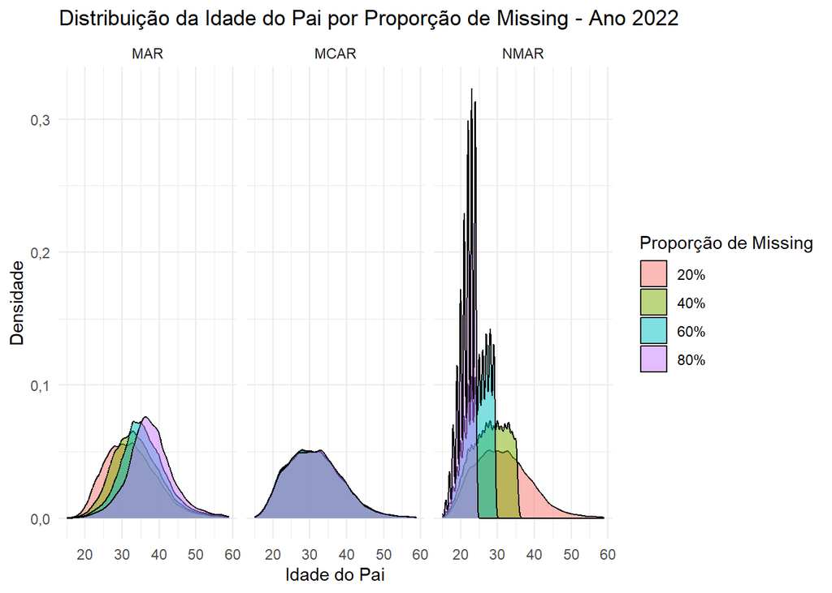

```r
library(ggplot2)
library(dplyr)


ano_escolhido <- 2022

# Criar um dataframe combinando diferentes níveis de missingness (MAR, MCAR, NMAR)
dados_combinados <- bind_rows(
  resultados_mar$MAR_20 |> mutate(Tipo = "MAR", Proporcao = "20%"),
  resultados_mar$MAR_40 |> mutate(Tipo = "MAR", Proporcao = "40%"),
  resultados_mar$MAR_60 |> mutate(Tipo = "MAR", Proporcao = "60%"),
  resultados_mar$MAR_80 |> mutate(Tipo = "MAR", Proporcao = "80%"),
  resultados_mcar$MCAR_20 |> mutate(Tipo = "MCAR", Proporcao = "20%"),
  resultados_mcar$MCAR_40 |> mutate(Tipo = "MCAR", Proporcao = "40%"),
  resultados_mcar$MCAR_60 |> mutate(Tipo = "MCAR", Proporcao = "60%"),
  resultados_mcar$MCAR_80 |> mutate(Tipo = "MCAR", Proporcao = "80%"),
  resultados_nmar$NMAR_20 |> mutate(Tipo = "NMAR", Proporcao = "20%"),
  resultados_nmar$NMAR_40 |> mutate(Tipo = "NMAR", Proporcao = "40%"),
  resultados_nmar$NMAR_60 |> mutate(Tipo = "NMAR", Proporcao = "60%"),
  resultados_nmar$NMAR_80 |> mutate(Tipo = "NMAR", Proporcao = "80%")
) |> filter(Ano == ano_escolhido)  # Filtra para o ano escolhido

# Plotar distribuições de densidade
ggplot(dados_combinados, aes(x = IDADEPAI, fill = Proporcao)) +
  geom_density(alpha = 0.5) +
  facet_wrap(~ Tipo) +  # Separa os gráficos por mecanismo de missing
  labs(title = paste("Distribuição da Idade do Pai por Proporção de Missing - Ano", ano_escolhido),
       x = "Idade do Pai",
       y = "Densidade",
       fill = "Proporção de Missing") +
  theme_minimal()
```

## Boxplots dos dados com mecanismos de missing simulados

Os boxplots mostram mediana, quartis e outliers para IDADEPAI em diferentes proporções de missing dentro do mesmo ano.

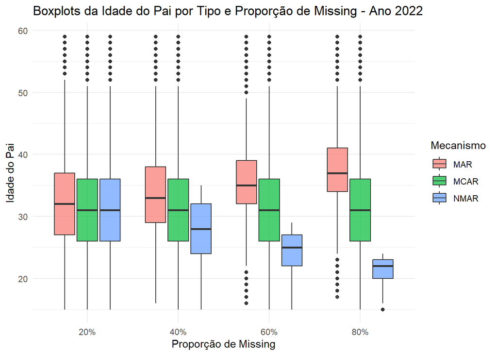

```r
ggplot(dados_combinados, aes(x = Proporcao, y = IDADEPAI, fill = Tipo)) +
  geom_boxplot(alpha = 0.7) +
  labs(title = paste("Boxplots da Idade do Pai por Tipo e Proporção de Missing - Ano", ano_escolhido),
       x = "Proporção de Missing",
       y = "Idade do Pai",
       fill = "Mecanismo") +
  theme_minimal()
```

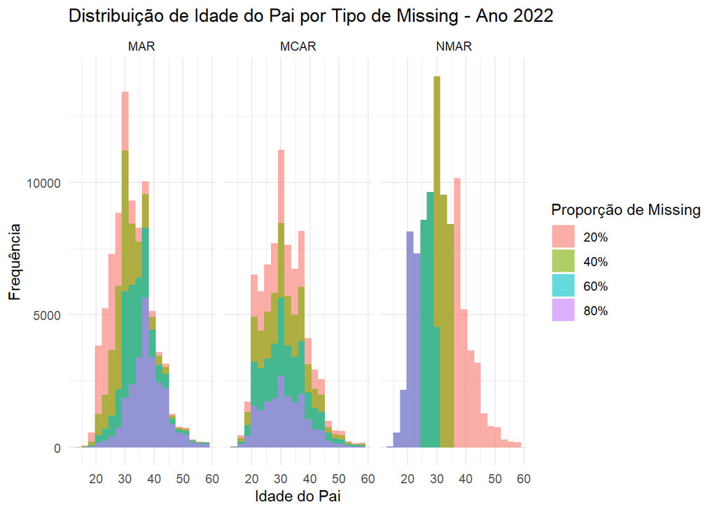

```r
ggplot(dados_combinados, aes(x = IDADEPAI, fill = Proporcao)) +
  geom_histogram(alpha = 0.6, bins = 20, position = "identity") +
  facet_wrap(~ Tipo) +
  labs(title = paste("Distribuição de Idade do Pai por Tipo de Missing - Ano", ano_escolhido),
       x = "Idade do Pai",
       y = "Frequência",
       fill = "Proporção de Missing") +
  theme_minimal()
```

# IMPUTAÇÃO POR ANO USANDO PMM DO PACOTE MICE

# testar: mice(df, method = c(“pmm”, “cart”, “rf”), m = 5)

```
pmm → Predictive Mean Matching
cart → Árvores de decisão
norm → Regressão normal
rf → Random Forest (se os dados forem grandes)
```